# RSV (ABRYSVO) - Exposure during pregnancy

OpenSourcePV

Data Lock Point: 2024_01_26

# 1 Quantitative Signal status

## 1.1 Disproportionality

The vaccine-event combination “RSV (ABRYSVO) - Exposure during pregnancy” was **a signal of disproportionate reporting** with an EB05 value of 8.01.

The threshold for being flagged as a signal of disproportionate reporting is an EB05>=2 meaning that there there is a 95% probability that the reporting of Exposure during pregnancy was at least twice post exposure to RSV (ABRYSVO) than post all vaccines [1]. Under the assumption of no causality between RSV (ABRYSVO) and Exposure during pregnancy and no bias it would have been expected to observe an EBGM of 1.

It means that the quantified causality criterion of strength of association is **met**.

*It is to be noted that the nature of the spontaneous report does not provide reliable estimates of the strength of association (whatever the choice of the disproportionality method) and that some reporting bias or difference in demographic characteristics might explain the (un)observed disproportion*.

## 1.2 Time-to-onset

The vaccine-event combination “RSV (ABRYSVO) - Exposure during pregnancy” was **not a signal of unexpected time-to-onset distribution** with a p-value of the two-sample Kolmogorov-Smirnov test being 0.0059405 and distance between the two empirical cumulative distributions being of 22.9024171%.

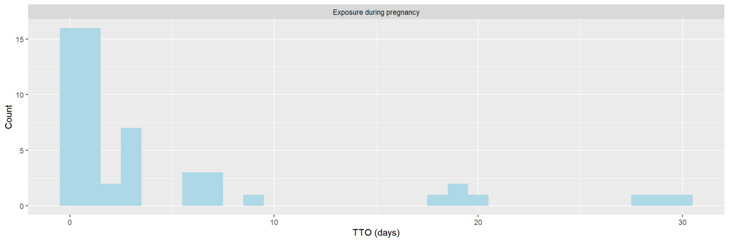

The TTO signal detection method tests if the distribution of Exposure during pregnancy post RSV (ABRYSVO) is significantly different from the distribution of Exposure during pregnancy post other vaccines using a two-sample Kolmogorov-Smirnov test [2]. The threshold for being flagged as a signal of unexpected time-to-onset distribution is a P-value <0.001 and a distance between the two empirical distributions larger than 20%. Under the assumption of no causality and no bias, it would have been expected that the time-to-onset distribution for “Exposure during pregnancy” would have been the same post RSV (ABRYSVO) than post other vaccines.

It means that the quantified causality criterion of temporality is **not met**.

*It is to be noted that the nature of the spontaneous report does not provide reliable estimates of the temporal relationship between the exposure and the occurrence of the events as there is the reporting bias over time: the latter the event occurs after exposure, the less chance it has to be reported. Other biases could distort the reported time-to-onset distribution (media attention, etc.)*

## 1.3 Overall

Based on the screening of the Empirical Bayes Geometric Mean (EBGM) and the screening of the time-to-onset distribution,the vaccine-event combination “RSV (ABRYSVO) - Exposure during pregnancy” is **considered as quantitative signal**.

# 2 Signal History

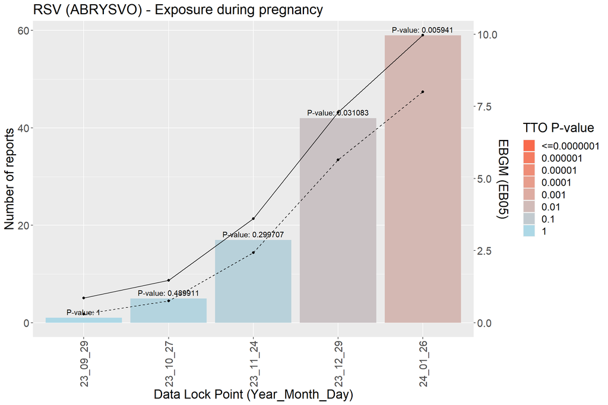

# 3 Case series

## 3.1 Seriousness

A total of 59 reports of Exposure during pregnancy were received post exposure to RSV (ABRYSVO). Among them:

- 0 (0.0 %) were fatal cases.
- 0 (0.0 %) were life threatening cases.
- 25 (42.4 %) were hospitalized cases.
- 0 (0.0 %) were emergency room cases.
- 1 (1.7 %) were cases with disabilies.

## 3.2 Demographic characteristics

59 cases of Exposure during pregnancy post RSV (ABRYSVO) were reported in VAERS:

- Among them, there were 57 (96.6%) female cases and 0 (0%) male cases while the overall female:male ratio is 62:28%.
- The mean (median) age for patients presenting symptoms of Exposure during pregnancy was 32 (32) years while the overall mean (median) age was 69 (72) years.
- The top 5 contributing US states for patients presenting symptoms of Exposure during pregnancy were PA ( 8.5 %) , NA ( 8.5 %) , IN ( 6.8 %) , TX ( 6.8 %) , VA ( 6.8 %) while overall the top 5 of contributing US states are NA ( 12.4 %) , CA ( 6.4 %) , NY ( 5.2 %) , OH ( 5.2 %) , PA ( 5 %)

# 4 Manufacturing

# 5 Listing of the cases

Narratives can be made visible clicking on the ⊕ symbol.

|  | VAERS ID | Sex/Age (Years) | Receipt Date | Seriousness status | List of symptoms | New | SYMPTOM_TEXT |
| --- | --- | --- | --- | --- | --- | --- | --- |
| &oplus; | 2728528 | F/30 | 12/29/2023 |  | Exposure during pregnancy, Injection site erythema, Injection site pruritus | Yes | Patient 35 weeks pregnant EDD 1 11 2024 Pruritis and erythema at site of injection |
| &oplus; | 2729412 | F/34 | 01/03/2024 | Hospitalized | Delivery, Exposure during pregnancy, Foetal heart rate deceleration abnormality, Premature labour, Prenatal screening test, Primigravida, Ultrasound antenatal screen normal | Yes | First pregnancy EDD 1 20 2024 Went into labor at 36 weeks and 4 days gestation age SVD at 36 weeks and 5 days gestation age on 12 28 2023 Pregnancy uncomplicated with normal prenatal labs Occasional l… |
| &oplus; | 2729555 | F/31 | 01/03/2024 |  | Exposure during pregnancy, Hand-foot-and-mouth disease | Yes | Developed hand foot mouth disease on 12 28 2023 I do not believe this was associated with the vaccine but rather an illness I picked up from my son who brought it home from daycare Have previously bee… |
| &oplus; | 2729869 | F/34 | 01/04/2024 | Hospitalized | Exposure during pregnancy, Premature delivery | Yes | Preterm birth |
| &oplus; | 2730132 | F/30 | 01/05/2024 |  | Abdominal pain upper, Back pain, Exposure during pregnancy, Nausea, Pain in extremity, Sciatica | Yes | Delivery date 34 weeks pregnant 3rd pregnancy 1 miscarriage in 2021 Adverse event from rsv vaccine nausea lower back and sciatic leg pain weakness and mild stomach pain |
| &oplus; | 2730139 | F/35 | 01/05/2024 |  | Exposure during pregnancy, Extra dose administered, No adverse event | Yes | n a Patient received vaccine twice in 1 week Once on 1 3 24 during obstetrics visit and another on 1 5 24 during another obstetrics visit No adverse affects noted after 15 minutes of observation Patie… |
| &oplus; | 2730146 | F/33 | 01/05/2024 |  | Exposure during pregnancy, Musculoskeletal stiffness, Neck pain | Yes | 34 weeks pregnant Neck pain and stiffness on left side same side as vaccine |
| &oplus; | 2731661 | F/32 | 01/11/2024 |  | Brain fog, Exposure during pregnancy, Fatigue, Nausea, Pain, Rhinorrhoea | Yes | G4P1021 Current pregnancy due date 3 2 24 current weight of patient 204 lbs Patient reports nausea generalized body aches and increased fatigue brain fog runny nose |
| &oplus; | 2732112 | F/32 | 01/12/2024 |  | Exposure during pregnancy, Injection site erythema, Injection site pain, Injection site swelling, Injection site warmth | Yes | 34 weeks pregnant received vaccination and needle did not initially break skin on left non dominant arm vaccine was attempted again in right arm more forcefully Injection site is warm swollen red and … |
| &oplus; | 2732151 | F/33 | 01/12/2024 |  | Exposure during pregnancy, Extra dose administered, No adverse event | Yes | Pt was given a dose of Abrysvo on 12 15 2023 at 32 weeks gestation and then in clinic again at 36 weeks gestation was given another dose on 1 12 2024 Pt was counseled by physician prior to administrat… |

[output cut: 49 more lines]

# 6 Disclaimer

This analysis is exploratory only and authors cannot be held responsible for any decision made using these data. It is important to distinguish quantitative signals such as disproportionate reporting, unexpected time-to-onset patterns or cluster from safety signals. Only a qualitative review using multiple data source (literature, clinical trials, etc.) and multiple causality criteria assessment could qualify quantitative signals into safety signals.

# 7 References

[1] Dumouchel W. Bayesian data mining in large frequency tables, with an application to the FDA spontaneous reporting system. Am Stat 1999; 53: 177–190.

[2] Van Holle L et al, Using time‐to‐onset for detecting safety signals in spontaneous reports of adverse events following immunization: a proof-of-concept study. Pharmacoepidemiology and Drug Safety 21 (6), 603-610.